# **Titanic data analysis**

## **Introduction**

This report presents an analysis of the Titanic data using the custom package “TitanicPackage”.

```r
library(carData)
library(TitanicPackage)
library(ggplot2)
```

## **Load of data**

```r
head(TitanicSurvival)
```

```
##                                 survived    sex     age passengerClass
## Allen, Miss. Elisabeth Walton        yes female 29.0000            1st
## Allison, Master. Hudson Trevor       yes   male  0.9167            1st
## Allison, Miss. Helen Loraine          no female  2.0000            1st
## Allison, Mr. Hudson Joshua Crei       no   male 30.0000            1st
## Allison, Mrs. Hudson J C (Bessi       no female 25.0000            1st
## Anderson, Mr. Harry                  yes   male 48.0000            1st
```

## **Descriptive statistics of variables**

```r
summary(TitanicSurvival)
```

```
##  survived      sex           age          passengerClass
##  no :809   female:466   Min.   : 0.1667   1st:323
##  yes:500   male  :843   1st Qu.:21.0000   2nd:277
##                         Median :28.0000   3rd:709
##                         Mean   :29.8811
##                         3rd Qu.:39.0000
##                         Max.   :80.0000
##                         NA's   :263
```

## **Visualization of the results**

#### Figure 1: Age distribution of passengers

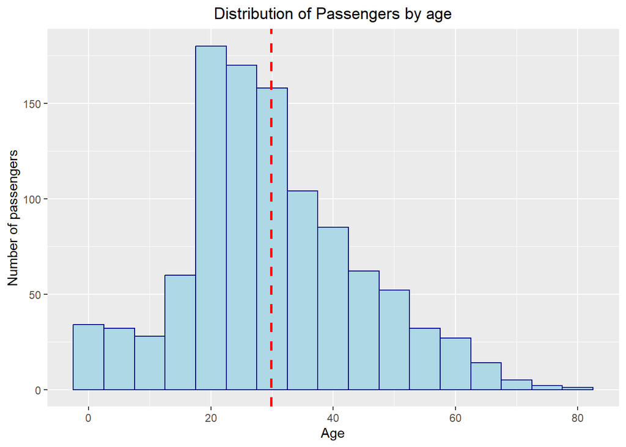

```r
ggplot(TitanicSurvival, aes(x=age))+
    geom_histogram(binwidth=5,color="darkblue",fill="lightblue")+
    geom_vline(aes(xintercept=mean(age, na.rm=TRUE)), color="red", linetype="dashed",  linewidth=1)+ labs(title = "Distribution of Passengers by age", x= "Age", y = "Number of passengers")+ theme(plot.title = element_text(hjust = 0.5))
```

#### Figure 2: Gender distribution of passengers

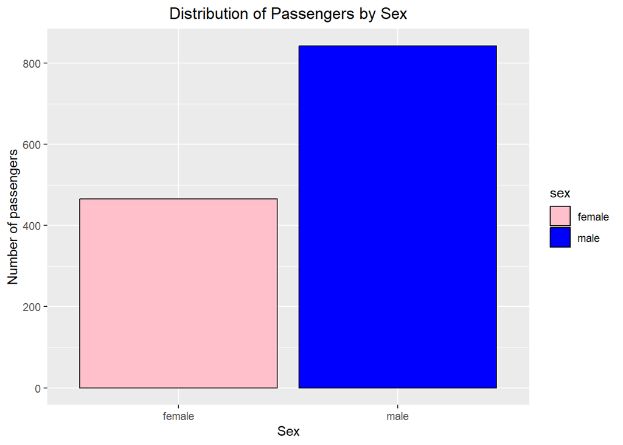

```r
ggplot(TitanicSurvival, aes(x=sex, fill = sex)) + geom_bar(color = "black")+ scale_fill_manual(values = c("female" = "pink", "male" = "blue"))+ labs(title = "Distribution of Passengers by Sex", x ="Sex", y = "Number of passengers")+ theme(plot.title = element_text(hjust = 0.5))
```

The above graph shows us the proportion of the sex of the passengers of the Titanic, we can see that there were more men than women.

#### Figure 3: Passenger Class distribution

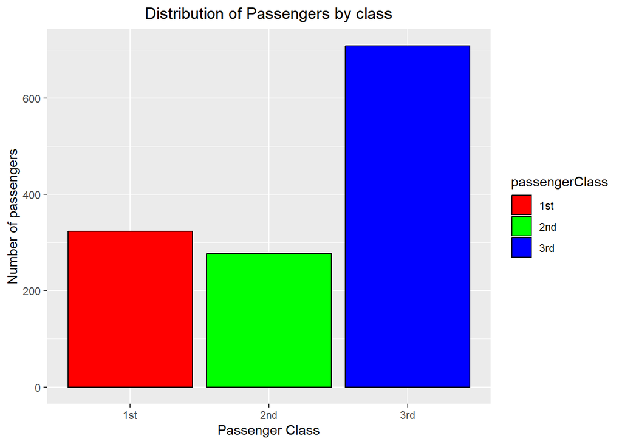

```r
ggplot(TitanicSurvival, aes(x=passengerClass, fill = passengerClass)) + geom_bar(color = "black")+ scale_fill_manual(values = c("1st" = "red", "2nd" = "green", "3rd" = "blue" ))+ labs(title = "Distribution of Passengers by class", x ="Passenger Class", y = "Number of passengers")+ theme(plot.title = element_text(hjust = 0.5))
```

The above graph shows us the proportion of different passenger classes, we see that the 1st and 2nd class have practically the same number of passengers, while the 3rd class represents the sum of the other 2 classes.

#### Figure 4: Passenger Survival distribution

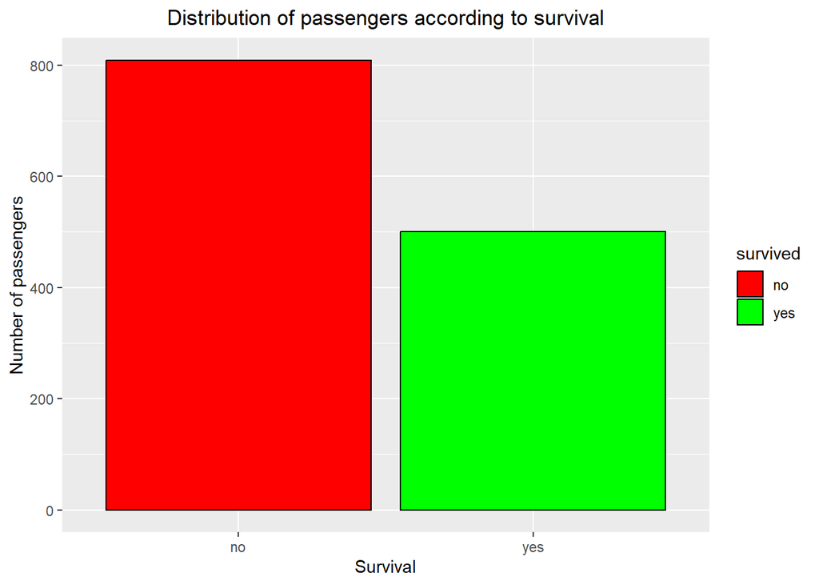

```r
ggplot(TitanicSurvival, aes(x=survived, fill = survived)) + geom_bar(color = "black")+ scale_fill_manual(values = c("yes" = "green", "no" = "red"))+ labs(title = "Distribution of passengers according to survival", x ="Survival", y = "Number of passengers")+ theme(plot.title = element_text(hjust = 0.5))
```

The above graph shows us the proportion of passengers who survived or not, we see that there were more deaths than survivors.

#### Figure 5: Distribution of Survivors by Sex and Class

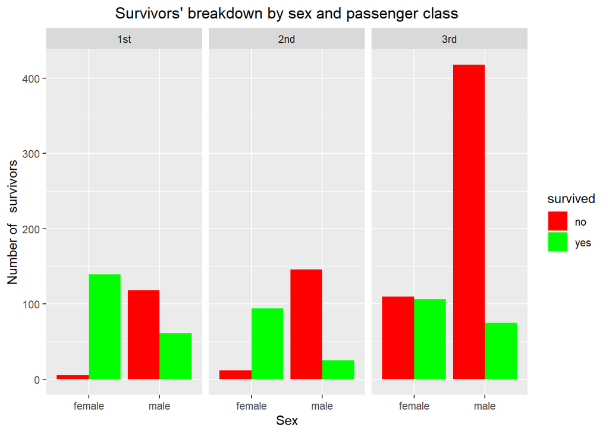

```r
ggplot(TitanicSurvival, aes(x = sex, fill = survived)) +
  geom_bar(position = "dodge") +
  scale_fill_manual(values = c("yes" = "green", "no" = "red"))+
  facet_wrap(~passengerClass) +
  labs(title = "Survivors' breakdown by sex and passenger class", x = "Sex", y = "Number of   survivors")+
  theme(plot.title = element_text(hjust = 0.5))
```

The above graph shows the proportion of passengers who survived according to sex and class, we see that in all classes women have a higher survival percentage compared to men, the 1st class having had the least deaths while the 3rd class had more deaths and which were mostly men.

#### Figure 6: Age distribution of survivors

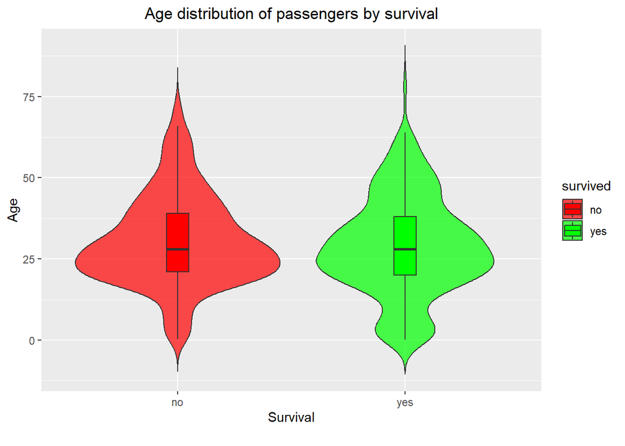

```r
ggplot(TitanicSurvival, aes(x = survived, y = age, fill = survived))+
  geom_violin(trim = FALSE, alpha = 0.7)+
  geom_boxplot(width = 0.1, outlier.shape = NA)+
  labs(title = "Age distribution of passengers by survival", x = "Survival
  ", y = "Age")+
  theme(plot.title = element_text(hjust = 0.5))+
  scale_fill_manual(values = c("no" = "red", "yes" = "green"))
```

The above graph is a violin plot showing the age distribution of passengers according to their survival. In summary, the graph suggests that younger passengers had a better chance of survival than older people, and the priorities were more children and women.

## **Passenger survival rates by class**

```r
TitanicPackage::taux_survie_classe(TitanicSurvival)
```

```
##   passengerClass  survived
## 1            1st 0.6191950
## 2            2nd 0.4296029
## 3            3rd 0.2552891
```

## **Passenger survival rates by sex**

```r
TitanicPackage::taux_survie_sexe(TitanicSurvival)
```

```
##      sex  survived
## 1 female 0.7274678
## 2   male 0.1909846
```

## **Conclusion**

In sum, the analysis shows that certain groups, especially women and higher classes had a higher survival rate than men and passengers of 3rd class.